# Kobe Advice Framework of the tuna RFMOs

Laurence Kell & Neils Hintzen

05 diciembre, 2016

# Introduction

The provision of fisheries management advice requires the assessment of stock status relative to reference points, the prediction of the response of a stock to management, and checking that predictions are consistent with reality.

Following the adoption of the Precautionary Approach to fisheries management Garcia (1996) an important principle of when providing advice is that the level of precaution should increase as uncertainty increases. This requires a consideration of risk, where risk is an uncertainty that matters and what matters are management objectives. There are two main ways to reduce risk when managing fish stocks, either by obtaining better information or implementing better management.

# The Kobe Advice Framework

The Tuna Regional Fisheries Management Organisations (tRFMOs) use a common advice framework known as the **Kobe Framework**.

The original objective of the tuna Regional Fisheries Management Organisations (tRFMOs) was to keep stocks at a level that will support MSY. Under the precautionary approach, however, it is no longer sufficient to just know where we are, we also need to consider the impact of uncertainty on our ability to achieve management objectives. This requires management objectives related to safety and stability as well as yield and to consider the trade-offs between them. Ideally indicators used to formulate advice should also not overlap in what they tell us.

To help implement the Precautionary Approach, and to meet multiple conflicting objectives, the tRFMOs are begining to simulation Harvest Control Rules (HCRs) using Management Strategy Evaluation (MSE). Where a HCR is a set of well-defined rules used for determining a management action in the form of a TAC or allowable fishing effort given input from an estimator or directly from data. This has meant a change in the way advice is developed and management implemented Kell et al. (2016).

## Atlantic Yellowfin Example

http://tuna-org.org/mse.htm http://groupspaces.com/tRFMO-MSE/wiki/ http://groupspaces.com/tRFMO-MSE/pages/meetings-kickoff http://rscloud.iccat.int/tRFMO-MSE/kickoff/albacore/ko_alb-cs_Iago-Kell.html#1

http://iccat.int/com2016/

How often advice is updated depends upon the dynamics of a stock and the management framework. For long lived species such as tuna where management regulations are agreed for a number of years, stock assessments are not conducted each year for every stock. For example Atlantic yellowfin was reassessed in 2016 following the last assessment in 2011.

In 2016 not only the data but the stock assessment models and scenarios changed. In 2011 two assessment methods were used, Virtual Population Analysis (VPA) and a biomass dynamic model, while in 2016 an Age Structured Production Model (ASPM) and an Integrated Statistical Model (Stock Synthesis) were also used. These assessment models span a range of complexity and data requirements, and the parameters that are estimated and/or fixed

### Assessment Models and data requirements

|  | Biomass | ASPM | VPA | SS |
| --- | --- | --- | --- | --- |
| Catch Biomass | x | x |  | x |
| Effort | x |  |  | x |
| Relative abundance |  |  | x |  |
| CPUE | x |  | x | x |
| Catch-at-size |  | x |  |  |
| Catch-at-age |  |  | x |  |
| Growth |  | x |  | x |
| Fecundity |  |  |  | x |
| Natural Mortality |  | x | x | x |
| Migration |  |  |  |  |
| Stock Structure |  |  |  |  |

#### Biomass Dynamic Models

These models are bases on aggregate biomass dynamics controlled by a low number of parameters: typically just K (carrying capacity), r (intrinsic growth rate), initial population biomass and a catchability coefficient related to fishing mortality. The shape of the production model can be chosen by specifying a different form of the production function.

#### Age Structure Production Model

In ASPM the population dynamics are full age structure, uses a spawner-recruitment relationship (the estimable parameters of which play the role of the r and K of the biomass dynamics models) and may or may not include estimation of stochastic annual deviations in recruitment; information on natural mortality, body weight-at-age, maturity-at-age and fishery selection-at-age must be specified by the user; each fleet included in the model, and each abundance index used in the model fitting, can have its unique ageselection, so essentially this is a superset of the capabilities of the delay-difference, two-stage models. The population dynamics in an age-structured production model are carried forward into statistical catch-at-age and age -structured integrated analysis models.

#### Virtual Population Analysis

In a VPA population abundance at age is directly calculated from catch-at-age (treated as known and without error in every time step)and natural mortality, starting from the latest year and oldest true age for each cohort (excluding the plus group); treatment of the plus group varies among software packages; often incorporate fits to age-specific abundance indices; minimal assumptions concerning selection-at-age patterns.

#### Integrated Models

These models tend to be highly general with regard to the types of data that can be included and, on the whole, they strive to analyze data with as little preprocessing as possible, for example using length composition data and information in the age-length key directly, rather than inputting the derived age composition data to the model. Two sub-categories are defined based upon whether the population dynamics, internal to the model, are length or age based.

### Summary

One approach to address uncertainty in historical estimates of stock status is to integrate multiple diverse datasets to try and extract as much information as possible about modelled processes. An implicit assumption is that integrated models can compensate for lack of good data. Models are by defini- tion, however, simplifications of reality and model misspecification can lead to degradation of results when there are multiple potentially conflicting data sets. Including all available data in stock assessments may lead to high noise levels and poor-quality assessments, the choice of data should be based on rational and justifiable selection criteria. It is therefore critical to determine what drives an assessment.

### Global Albacore tRFMO Case Study

rscloud.iccat.int//kickoff/themes/albacore/alb-cs.html#1

## Historical Trends

The four methods are based on different assumptions about the dynamics

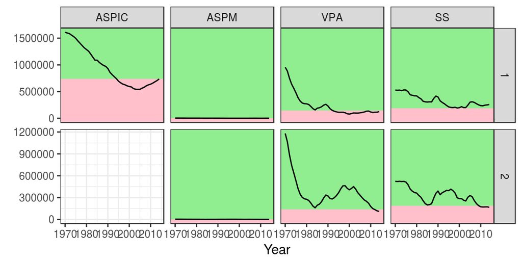

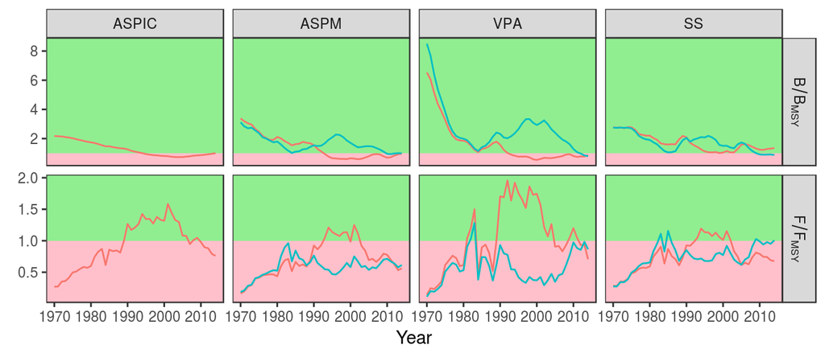

**Figure 2.** Estimates relative to reference points

## Advice Plots

Two main visualisation tools are used as part of the Kobe Framework to present stock assessment advice, namely the Kobe II phase plot (K2PP) and the Kobe II strategy matrix (K2SM). The K2PP presents stock status against fishing mortality relative to Target Reference Points as a two-dimensional phase plot. The K2SM lays out the probability of meeting management objectives under different options, including if necessary ending overfishing or rebuilding overfished stocks. Presenting advice in the K2SM format is intended to facilitate the application of the PA by providing Commissions with a basis to evaluate and adopt management options at various levels of risk (Anonymous, 2009). This enables Commissioners to make management recommendations while taking some sources of uncertainty into account. As an exception the CCSBT does not use the K2SM, since they prefer to consider other performance measures (related to catch levels and catch variability) as well as stock status.

### Phase Plots

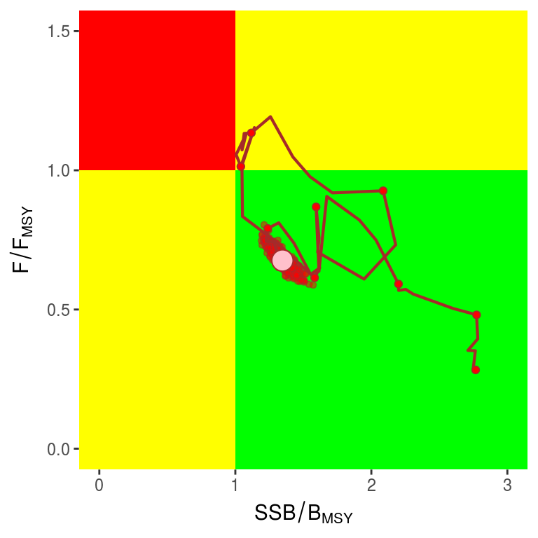

**Figure 3.** Uncertainty in current estimates

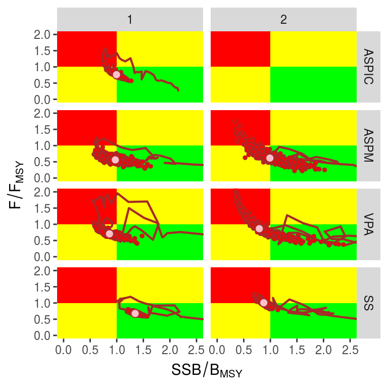

**Figure 4.** Phase plots

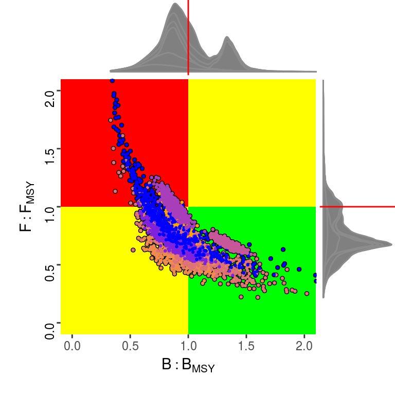

**Figure 5.** Phase plot

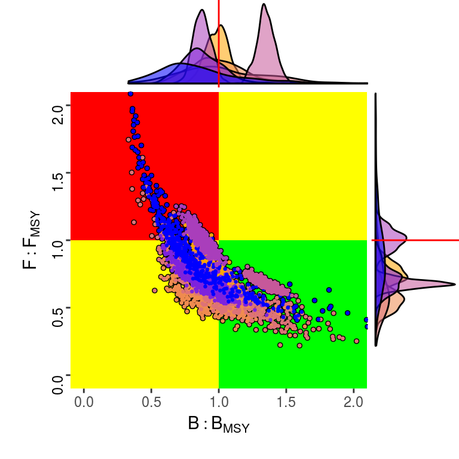

**Figure 6.** Phase plot

### Strategy Matrix

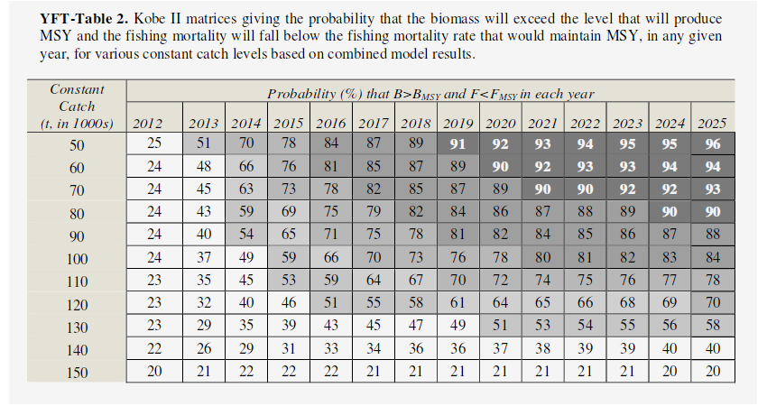

**Figure 7.** Strategey matrix

#### Decision table

IATTC prefer to use a decision table, this differs from the K2SM in that it provide a a range of performance measures for a set of alternative management actions under different states of nature.

```
  Scenario Method year    tac
1        1  ASPIC 2017 150000
2        1   ASPM 2017  50000
3        2   ASPM 2017  50000
4        1    VPA 2017  50000
5        2    VPA 2017  50000
6        1     SS 2017  60000
7        2     SS 2019  60000
```

```
  Method Scenario year    tac
1  ASPIC        1 2018 110000
2   ASPM        1 2018 110000
3   ASPM        2 2018  80000
4    VPA        1 2018 100000
5    VPA        2 2018 110000
6     SS        1 2018 130000
7     SS        2 2018  90000
```

# References

Garcia, SM. 1996. “The Precautionary Approach to Fisheries and Its Implications for Fishery Research, Technology and Management: An Updated Review.” *FAO Fisheries Technical Paper*, 1–76.

Kell, Laurence T, Polina Levontin, Campbell R Davies, Shelton Harley, Dale S Kolody, Mark N Maunder, Iago Mosqueira, Graham M Pilling, and Rishi Sharma. 2016. “The Quantification and Presentation of Risk.” *Management Science in Fisheries: An Introduction to Simulation-Based Methods*. Oxford, UK: Earthscan (Routledge), 348.